# King Sejong’s National Poll on Tax Reform(Korean)

coop711

2015년 3월 29일

## Data Management

- 원자료는 세종실록, 요약표는 오기수 교수의 논문에서.

| region | class | vote | counts |
| --- | --- | --- | --- |
| 서울 | 대신 등 | 찬성 | 21 |
| 서울 | 대신 등 | 반대 | 194 |
| 서울 | 3품이하현직 | 찬성 | 259 |
| 서울 | 3품이하현직 | 반대 | 393 |
| 서울 | 3품이하전직 | 찬성 | 443 |
| 서울 | 3품이하전직 | 반대 | 117 |
| 유후사 | 품관촌민 | 찬성 | 1123 |
| 유후사 | 품관촌민 | 반대 | 71 |
| 경기 | 수령 | 찬성 | 29 |
| 경기 | 수령 | 반대 | 5 |
| 경기 | 품관촌민 | 찬성 | 17076 |
| 경기 | 품관촌민 | 반대 | 236 |
| 평안 | 대신 등 | 반대 | 1 |
| 평안 | 수령 | 찬성 | 6 |
| 평안 | 수령 | 반대 | 35 |
| 평안 | 품관촌민 | 찬성 | 1326 |
| 평안 | 품관촌민 | 반대 | 28474 |
| 황해 | 수령 | 찬성 | 17 |
| 황해 | 수령 | 반대 | 17 |
| 황해 | 품관촌민 | 찬성 | 4454 |
| 황해 | 품관촌민 | 반대 | 15601 |
| 충청 | 대신 등 | 반대 | 2 |
| 충청 | 수령 | 찬성 | 35 |
| 충청 | 수령 | 반대 | 26 |
| 충청 | 품관촌민 | 찬성 | 6982 |
| 충청 | 품관촌민 | 반대 | 14013 |
| 강원 | 수령 | 찬성 | 5 |
| 강원 | 수령 | 반대 | 10 |
| 강원 | 품관촌민 | 찬성 | 939 |
| 강원 | 품관촌민 | 반대 | 6888 |
| 함길 | 대신 등 | 반대 | 1 |
| 함길 | 수령 | 찬성 | 3 |
| 함길 | 수령 | 반대 | 14 |
| 함길 | 품관촌민 | 찬성 | 75 |
| 함길 | 품관촌민 | 반대 | 7387 |
| 경상 | 수령 | 찬성 | 55 |
| 경상 | 수령 | 반대 | 16 |
| 경상 | 품관촌민 | 찬성 | 36262 |
| 경상 | 품관촌민 | 반대 | 377 |
| 전라 | 대신 등 | 반대 | 2 |
| 전라 | 수령 | 찬성 | 42 |
| 전라 | 수령 | 반대 | 12 |
| 전라 | 품관촌민 | 찬성 | 29505 |
| 전라 | 품관촌민 | 반대 | 257 |

- 전체 찬반을 `xtabs()` 로 파악. `digits=3`의 역할에 유의

| 찬성 | 반대 |
| --- | --- |
| 98657 | 74149 |

```
## vote
##  찬성  반대
## 0.571 0.429
```

- `col=` 을 이용하여 색으로 찬반구분.

```
sejong.poll.kr.2$color[sejong.poll.kr.2$vote=="찬성"]<-"cyan"
sejong.poll.kr.2$color[sejong.poll.kr.2$vote=="반대"]<-"red"
```

- 윗 식을 한줄로 줄이려면 `ifelse()`를 이용하여

```
color<-ifelse(sejong.poll.kr.2$vote=="찬성", "cyan", "red")
```

```r
par(family = "나눔고딕")
pie(xtabs(counts~vote, data=sejong.poll.kr.2), col=c("cyan", "red"))
title(main="전체 찬반")
text(x=0, y=c(0.4,-0.4), labels=c("98,657", "74,149"))
```

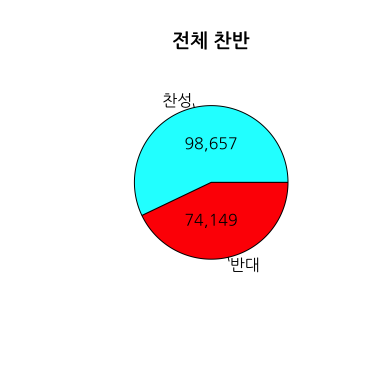

[figure not shown]

```r
dev.copy(png, file = "../pics/sejong_pie1.png", width = 960, height = 540)
```

- 계급별 찬반.

```r
xtabs(counts~vote+class, data=sejong.poll.kr.2)
```

```
##       class
## vote   대신 등 3품이하현직 3품이하전직  수령 품관촌민
##   찬성      21         259         443   192    97742
##   반대     200         393         117   135    73304
```

```r
kable(xtabs(counts~vote+class, data=sejong.poll.kr.2))
```

|  | 대신 등 | 3품이하현직 | 3품이하전직 | 수령 | 품관촌민 |
| --- | --- | --- | --- | --- | --- |
| 찬성 | 21 | 259 | 443 | 192 | 97742 |
| 반대 | 200 | 393 | 117 | 135 | 73304 |

```r
kable(round(prop.table(xtabs(counts ~ vote + class, data = sejong.poll.kr.2), margin = 2)*100, digits = 2), caption = "계급별 찬반(%)")
```

계급별 찬반(%)

|  | 대신 등 | 3품이하현직 | 3품이하전직 | 수령 | 품관촌민 |
| --- | --- | --- | --- | --- | --- |
| 찬성 | 9.5 | 39.7 | 79.1 | 58.7 | 57.1 |
| 반대 | 90.5 | 60.3 | 20.9 | 41.3 | 42.9 |

- 품관촌민의 수효가 상대적으로 많아서 별도로 분석.

```r
sejong.poll.kr.2$class.2<-ifelse(sejong.poll.kr.2$class=="품관촌민", "품관촌민", "관료")
```

- 관료와 품관촌민의 찬반 집계

```r
kable(xtabs(counts~vote+class.2, data=sejong.poll.kr.2))
```

|  | 관료 | 품관촌민 |
| --- | --- | --- |
| 찬성 | 915 | 97742 |
| 반대 | 845 | 73304 |

- 소계를 교차표의 주변에 계산.

```r
kable(addmargins(xtabs(counts~vote+class.2, data=sejong.poll.kr.2)))
```

|  | 관료 | 품관촌민 | Sum |
| --- | --- | --- | --- |
| 찬성 | 915 | 97742 | 98657 |
| 반대 | 845 | 73304 | 74149 |
| Sum | 1760 | 171046 | 172806 |

- 비율을 계산하여 주변에 집계.

```r
kable(prop.table(xtabs(counts~vote+class.2, data=sejong.poll.kr.2), margin=2))
```

|  | 관료 | 품관촌민 |
| --- | --- | --- |
| 찬성 | 0.52 | 0.571 |
| 반대 | 0.48 | 0.429 |

- 관료와 품관촌민의 찬반을 Pie chart에 도식화

```r
attach(sejong.poll.kr.2)
par(family = "나눔고딕")
par(mfrow=c(1,2))
pie(xtabs(counts~vote+class.2, data=sejong.poll.kr.2[class.2=="관료",], drop=T), labels=c("찬성", "반대"), col=c("cyan", "red"))
title(main="관료들의 찬반")
text(x=0, y=c(0.4,-0.4), labels=c("915", "845"))
pie(xtabs(counts~vote+class.2, data=sejong.poll.kr.2[class.2=="품관촌민",], drop=T), labels=c("찬성", "반대"), col=c("cyan", "red"))
title(main="품관촌민의 찬반")
text(x=0, y=c(0.4,-0.4), labels=c("97,742", "73,304"))
```

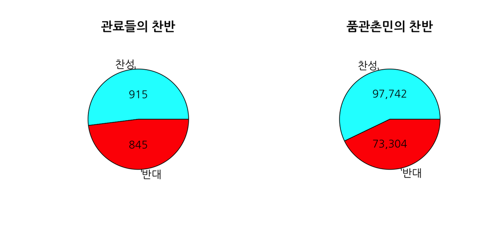

```r
par(mfrow=c(1,1))
```

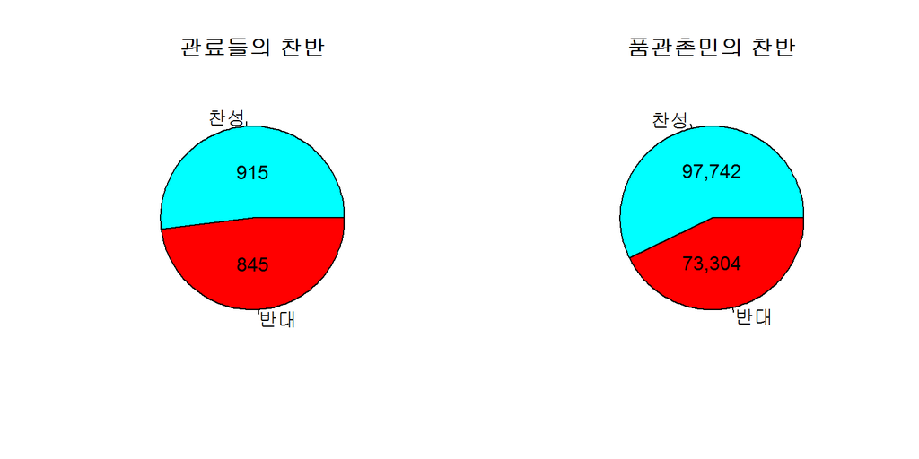

```r
par(mfrow=c(1,1))
dev.copy(png, file = "../pics/sejong_pie2.png", width = 960, height = 540)
```

- 관료와 품관촌민의 찬반을 지역별로 집계.

```r
kable(xtabs(counts~vote+region, data=sejong.poll.kr.2[class.2=="관료",], drop=T))
```

|  | 서울 | 경기 | 평안 | 황해 | 충청 | 강원 | 함길 | 경상 | 전라 |
| --- | --- | --- | --- | --- | --- | --- | --- | --- | --- |
| 찬성 | 723 | 29 | 6 | 17 | 35 | 5 | 3 | 55 | 42 |
| 반대 | 704 | 5 | 36 | 17 | 28 | 10 | 15 | 16 | 14 |

```r
kable(xtabs(counts~vote+region, data=sejong.poll.kr.2[class.2=="품관촌민",], drop=T))
```

|  | 유후사 | 경기 | 평안 | 황해 | 충청 | 강원 | 함길 | 경상 | 전라 |
| --- | --- | --- | --- | --- | --- | --- | --- | --- | --- |
| 찬성 | 1123 | 17076 | 1326 | 4454 | 6982 | 939 | 75 | 36262 | 29505 |
| 반대 | 71 | 236 | 28474 | 15601 | 14013 | 6888 | 7387 | 377 | 257 |

- 서울은 다른 지역보다 월등히 많은 관료가 거주하므로 별도 집계.

```r
kable(xtabs(counts~vote+class, data=sejong.poll.kr.2[region=="서울",], drop=T))
```

|  | 대신 등 | 3품이하현직 | 3품이하전직 |
| --- | --- | --- | --- |
| 찬성 | 21 | 259 | 443 |
| 반대 | 194 | 393 | 117 |

- 서울의 계급별 찬반을 barplot으로 그려봄. text()의 좌표는 locator()로 찾아냄.

```r
par(family = "나눔고딕")
barplot(xtabs(counts~vote+class, data=sejong.poll.kr.2[region=="서울",], drop=T), col=c("cyan", "red"))
title(main="서울의 찬반")
text(x=c(0.7, 1.9, 1.9, 3.1, 3.1), y=c(120, 450, 135, 500, 220), labels=c("194","393", "259", "117", "443"))
legend("topleft", inset=0.05, fill=c("cyan", "red"), legend=c("찬성", "반대"))
```

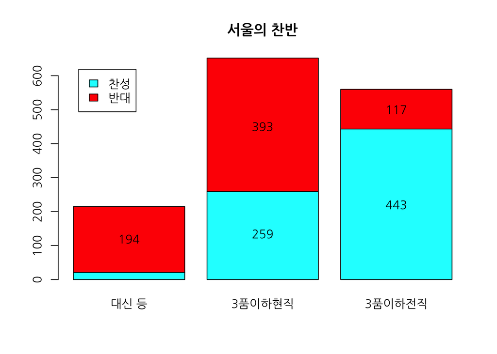

- mosaicplot()의 활용.

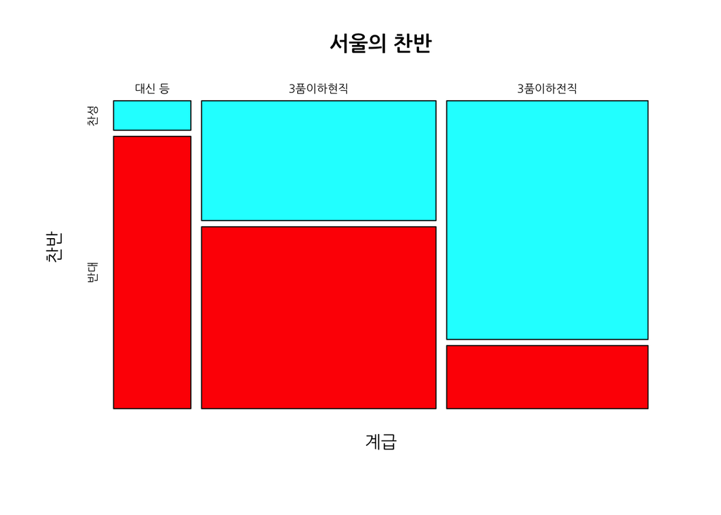

```r
par(family = "나눔고딕")
mosaicplot(xtabs(counts~class+vote, data=sejong.poll.kr.2[region=="서울",], drop=T), col=c("cyan", "red"), main="서울의 찬반", xlab="계급" , ylab ="찬반")
```

[figure not shown]

```r
dev.copy(png, file = "../pics/sejong_barplot1.png", width = 960, height = 540)
```

- mosaicplot()의 활용.

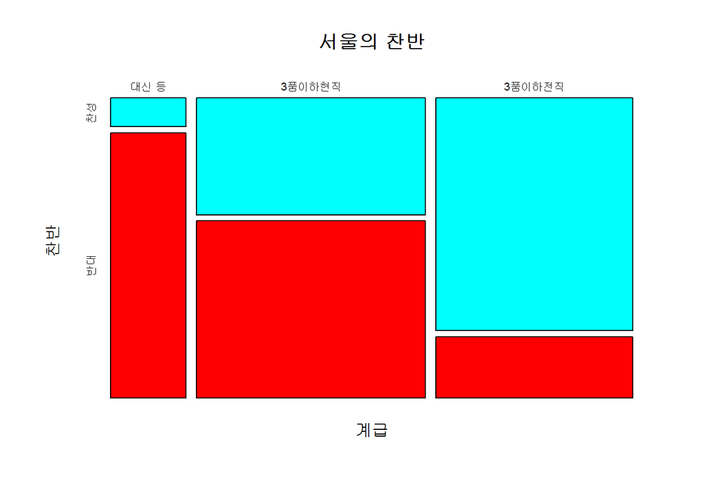

```r
mosaicplot(xtabs(counts~class+vote, data=sejong.poll.kr.2[region=="서울",], drop=T), col=c("cyan", "red"), main="서울의 찬반", xlab="계급" , ylab ="찬반")
```

```r
dev.copy(png, file = "../pics/sejong_mosaic1.png", width = 960, height = 540)
```

- 지역별 관료들의 찬반을 barplot()으로 그려봄.

```r
par(family = "나눔고딕")
kable(xtabs(counts~vote+region, data=sejong.poll.kr.2[class.2=="관료" & !region=="서울",], drop=T))
```

|  | 경기 | 평안 | 황해 | 충청 | 강원 | 함길 | 경상 | 전라 |
| --- | --- | --- | --- | --- | --- | --- | --- | --- |
| 찬성 | 29 | 6 | 17 | 35 | 5 | 3 | 55 | 42 |
| 반대 | 5 | 36 | 17 | 28 | 10 | 15 | 16 | 14 |

```r
barplot(xtabs(counts~vote+region, data=sejong.poll.kr.2[class.2=="관료" & !region=="서울",], drop=T), beside=TRUE, col=c("cyan", "red"))
title(main="지방 관료들의 찬반")
legend("topleft", inset=0.05, fill=c("cyan", "red"), legend=c("찬성", "반대"))
```

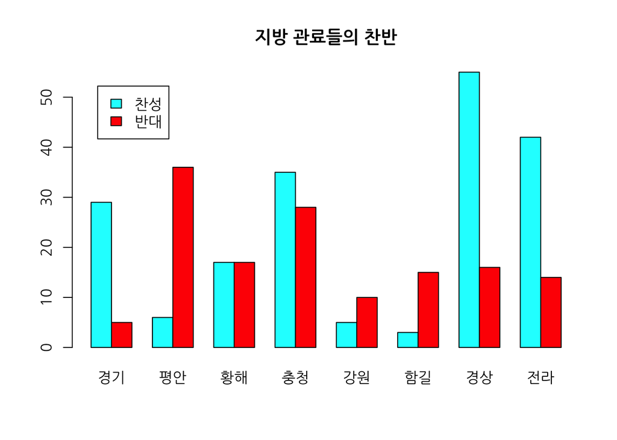

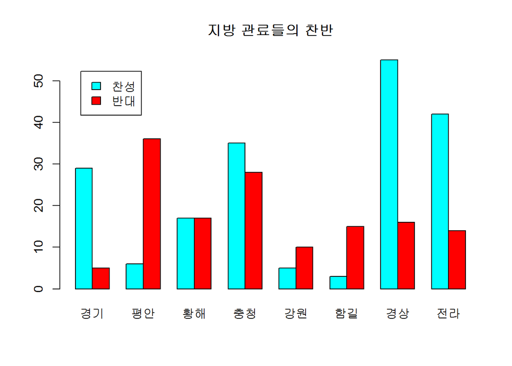

```r
dev.copy(png, file = "../pics/sejong_barplot2.png", width = 960, height = 540)
```

- mosaicplot()의 활용

```r
par(family = "나눔고딕")
mosaicplot(xtabs(counts~region+vote, data=sejong.poll.kr.2[class.2=="관료" & !region=="서울",], drop=T), col=c("cyan", "red"), main="", xlab="계급", ylab="찬반")
title(main="지방 관료들의 찬반")
```

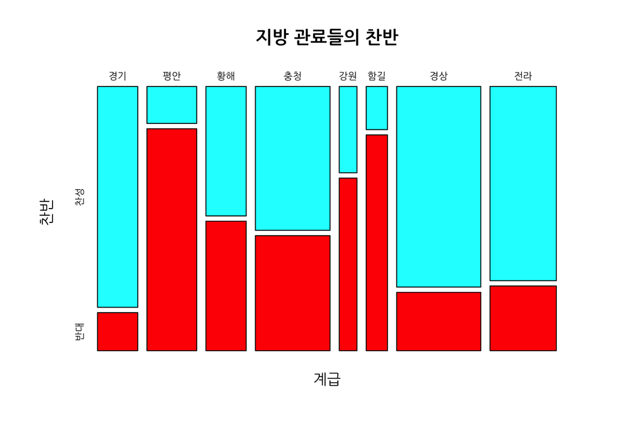

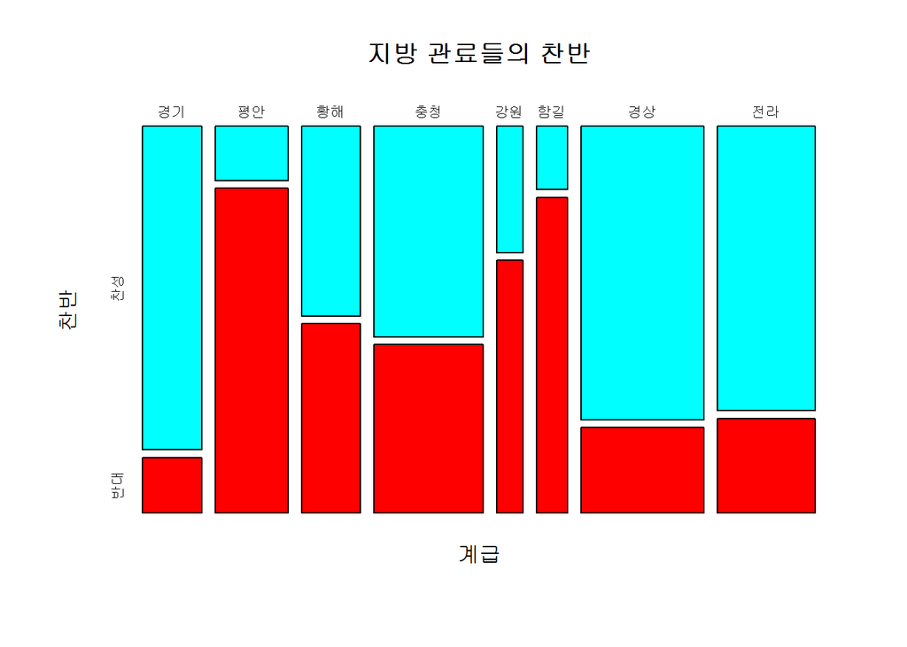

```r
dev.copy(png, file = "../pics/sejong_mosaic2.png", width = 960, height = 540)
```

- 품관촌민들의 지역별 찬반을 barplot()으로 요약.

```r
par(family = "나눔고딕")
barplot(xtabs(counts~vote+region, data=sejong.poll.kr.2[class.2=="품관촌민",], drop=T), beside=TRUE, col=c("cyan", "red"))
title(main="품관촌민들의 지역별 찬반")
legend("topleft", inset=0.05, fill=c("cyan", "red"), legend=c("찬성", "반대"))
```

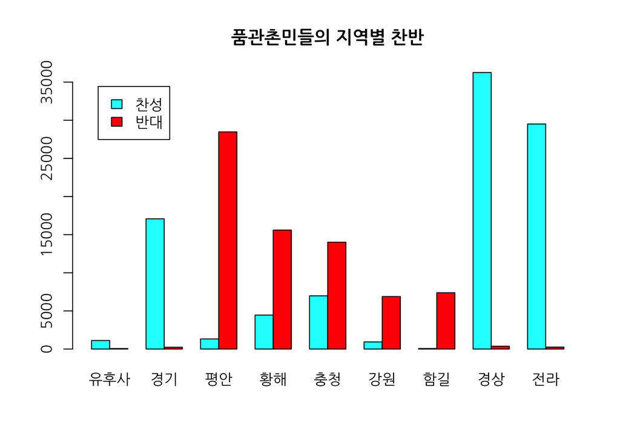

- mosaicplot()의 활용

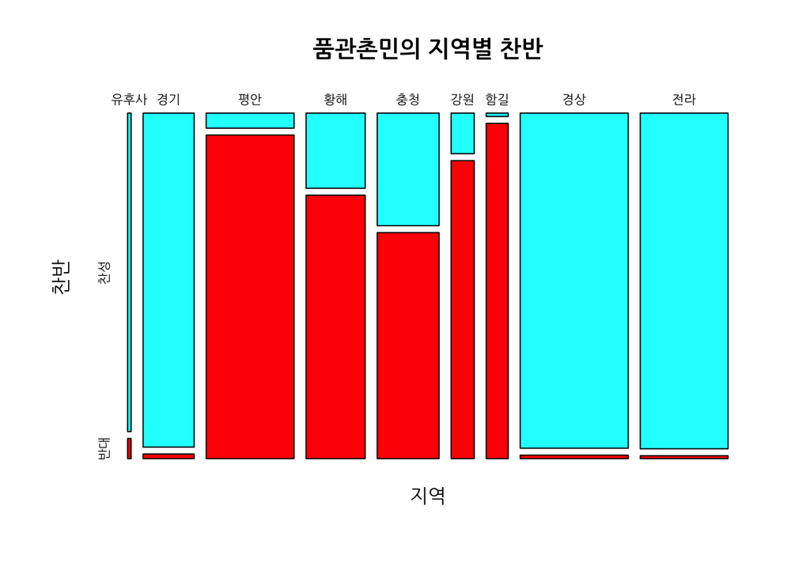

```r
par(family = "나눔고딕")
mosaicplot(xtabs(counts~region+vote, data=sejong.poll.kr.2[class.2=="품관촌민",], drop=T), col=c("cyan", "red"), main="품관촌민의 지역별 찬반", xlab="지역", ylab="찬반")
```

[figure not shown]

```r
dev.copy(png, file = "../pics/sejong_barplot3.png", width = 960, height = 540)
```

- mosaicplot()의 활용

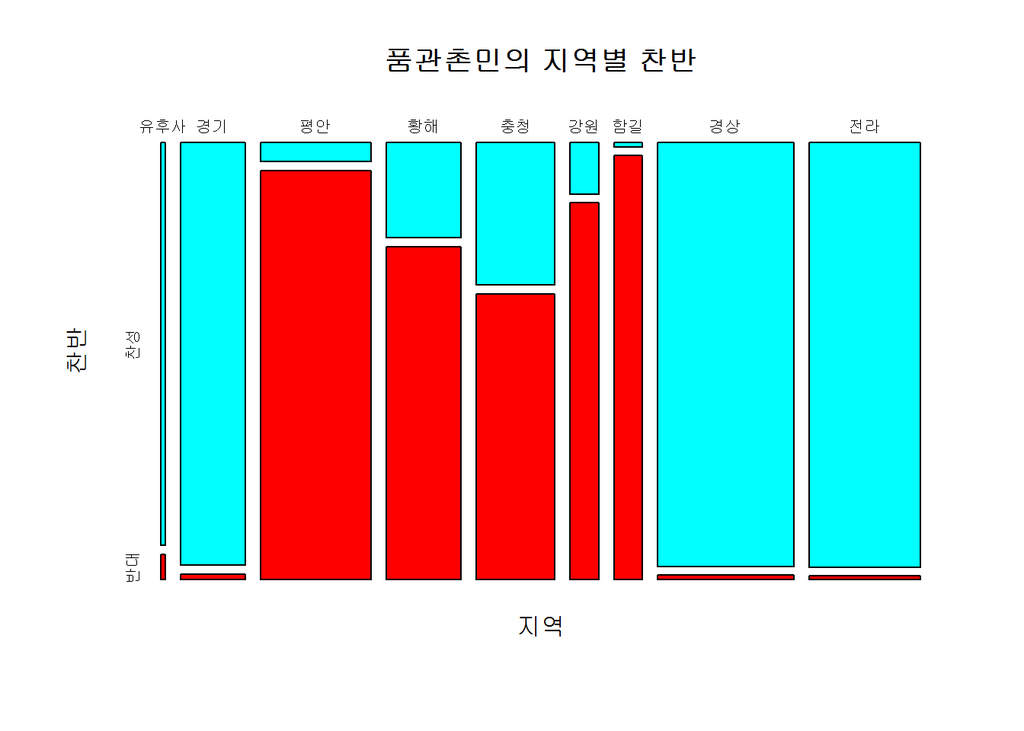

```r
mosaicplot(xtabs(counts~region+vote, data=sejong.poll.kr.2[class.2=="품관촌민",], drop=T), col=c("cyan", "red"), main="품관촌민의 지역별 찬반", xlab="지역", ylab="찬반")
```

```r
dev.copy(png, file = "../pics/sejong_mosaic3.png", width = 960, height = 540)
```

- 충청도는 관료들의 찬반과 품관촌민의 찬반이 다른 곳.

```r
par(family = "나눔고딕")
kable(xtabs(counts~vote+class, data=sejong.poll.kr.2[region=="충청",], drop=T))
```

|  | 대신 등 | 수령 | 품관촌민 |
| --- | --- | --- | --- |
| 찬성 | 0 | 35 | 6982 |
| 반대 | 2 | 26 | 14013 |

```r
kable(prop.table(xtabs(counts~vote+class, data=sejong.poll.kr.2[region=="충청",], drop=T), margin=2))
```

|  | 대신 등 | 수령 | 품관촌민 |
| --- | --- | --- | --- |
| 찬성 | 0 | 0.574 | 0.333 |
| 반대 | 1 | 0.426 | 0.667 |

```r
barplot(prop.table(xtabs(counts~vote+class, data=sejong.poll.kr.2[region=="충청",], drop=T), margin=2), col=c("cyan", "red"), ylim=c(0, 1.5), axes=F)
axis(side=2, at=c(0, 0.5, 1.0), labels=c("0", "50%", "100%"))
title(main="충청도의 계급별 찬반 비율")
legend("topleft", inset=0.05, fill=c("cyan", "red"), legend=c("찬성", "반대"))
text(x=c(0.7, 1.9, 1.9, 3.1, 3.1), y=c(0.5, 0.3, 0.8, 0.15, 0.65), labels=c(2, 35, 26, 6982, 14013))
```

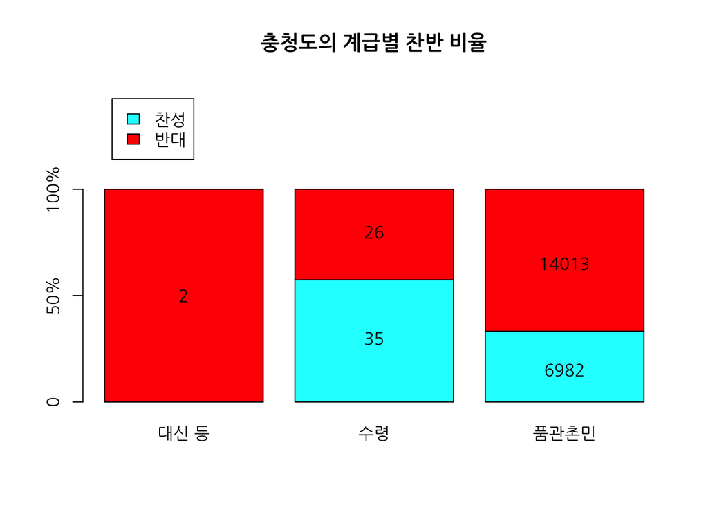

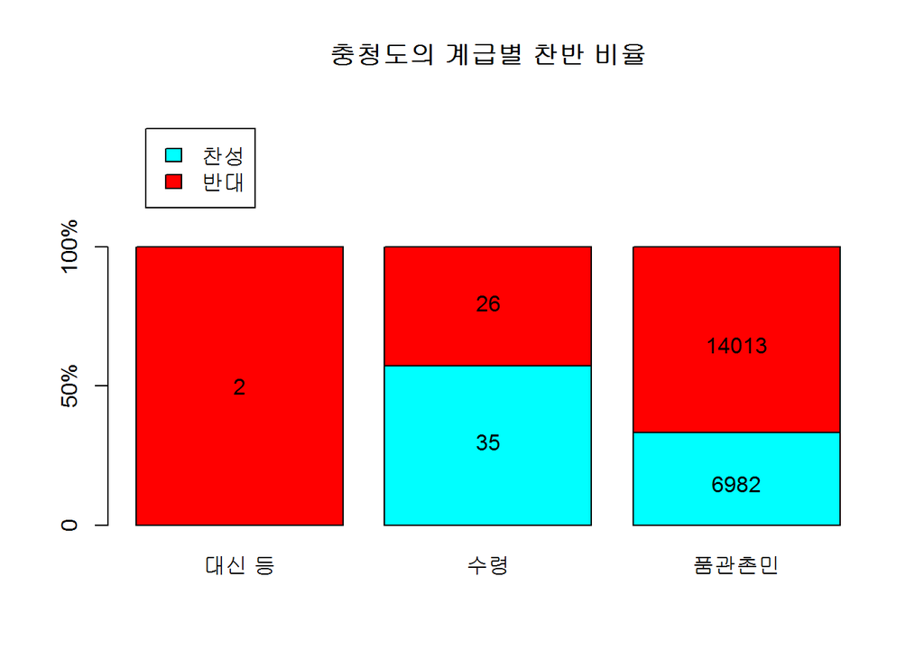

```r
dev.copy(png, file = "../pics/sejong_barplot4.png", width = 960, height = 540)
```

- mosaicplot()으로 수효의 차이가 너무 커서 비교하기 어려움.

```r
par(family = "나눔고딕")
mosaicplot(xtabs(counts~class+vote, data=sejong.poll.kr.2[region=="충청",], drop=T), col=c("cyan", "red"), main="", xlab="계급", ylab="찬반")
title(main="충청도의 찬반")
```

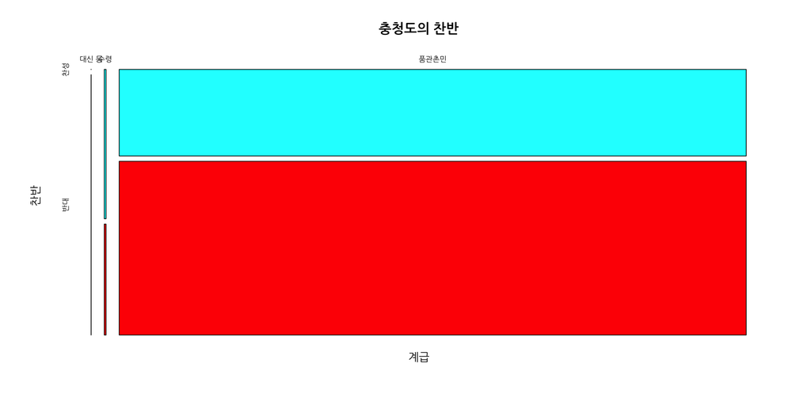

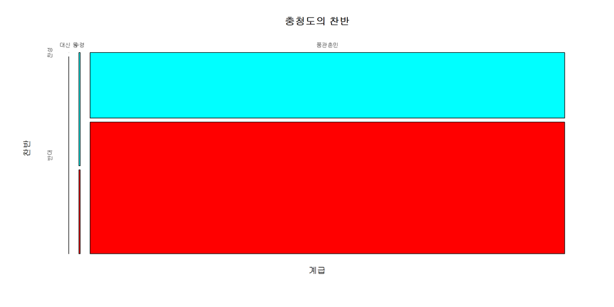

```r
dev.copy(png, file = "../pics/sejong_mosaic4.png", width = 960, height = 540)
```

- 작업 디렉토리의 이미지와 히스토리를 저장하고 퇴장.

```
save.image(file="sejong_poll1202.rda")
savehistory(file="sejong_poll0328.Rhistory")
q("no")
```